# Major Wheater Events in the US: Period 1950 - 2011

Peer-graded Assignment: Course Project 2

Carlos Sanchez

15 February 2021

# Synopsis

The following study analyzes data from the [U.S. National Oceanic and Atmospheric Administration’s (NOAA) storm database](https://www.ncdc.noaa.gov/stormevents/) from different points of view. This database includes information about:

1. Storms and other significant weather phenomena that have provoked injuries or fatalities to people and crop or property damages
2. Rare weather phenomena
3. Other meteorological events that occur combined with another event

The current study includes the data collected between the years 1950 and 2011. Data from last years are more complete and of better quality.

# Data Processing

First we load the data from the internet source:

```r
zipFile <- "StormData.bz2"

if(!file.exists(zipFile)){
fileUrl <- "https://d396qusza40orc.cloudfront.net/repdata%2Fdata%2FStormData.csv.bz2"
download.file(fileUrl, destfile = "StormData.bz2")
}

StormData <- read.csv("StormData.bz2")
```

Once loaded, we analyze the dataset dimensions and the different variables we have. We can see that we have 902297 rows and 37 variables. We can also see the first rows of the dataset:

```r
dim(StormData)
```

```
## [1] 902297     37
```

```r
head(StormData)
```

```
##   STATE__           BGN_DATE BGN_TIME TIME_ZONE COUNTY COUNTYNAME STATE  EVTYPE
## 1       1  4/18/1950 0:00:00     0130       CST     97     MOBILE    AL TORNADO
## 2       1  4/18/1950 0:00:00     0145       CST      3    BALDWIN    AL TORNADO
## 3       1  2/20/1951 0:00:00     1600       CST     57    FAYETTE    AL TORNADO
## 4       1   6/8/1951 0:00:00     0900       CST     89    MADISON    AL TORNADO
## 5       1 11/15/1951 0:00:00     1500       CST     43    CULLMAN    AL TORNADO
## 6       1 11/15/1951 0:00:00     2000       CST     77 LAUDERDALE    AL TORNADO
##   BGN_RANGE BGN_AZI BGN_LOCATI END_DATE END_TIME COUNTY_END COUNTYENDN
## 1         0                                               0         NA
## 2         0                                               0         NA
## 3         0                                               0         NA
## 4         0                                               0         NA
## 5         0                                               0         NA
## 6         0                                               0         NA
##   END_RANGE END_AZI END_LOCATI LENGTH WIDTH F MAG FATALITIES INJURIES PROPDMG
```

[output cut: 20 more lines]

# Results

### Across the United States, which types of events (as indicated in the `EVTYPE` variable) are most harmful with respect to population health?

To answer this question, we will group the data by `EVTYPE` variables and will summarize the total number of Fatalities and Injuries that each event has caused.

```r
StormData_death_injured <- StormData %>% group_by(EVTYPE) %>% summarise(TotalFatalities = sum(FATALITIES), TotalInjuries = sum(INJURIES)) %>% arrange(desc(TotalFatalities))

colors <- c("Total Injuries" = "blue", "Total Fatalities" = "red")
```

For clarity purposes, we will plot the 10 most harmful events in decreasing order of fatalities. We can see the two series, Total Fatalities in red and Total Injuries in blue.

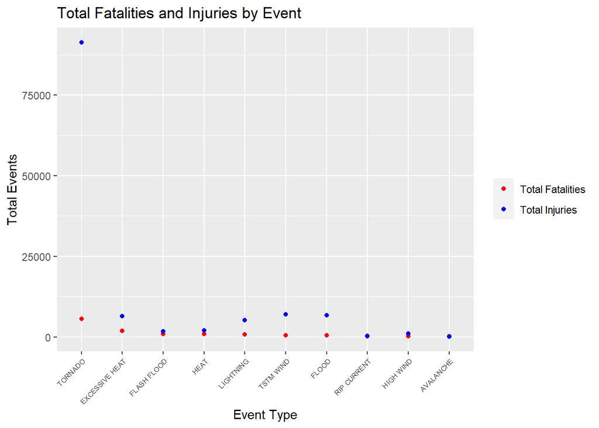

```r
   ggplot(head(StormData_death_injured, 10)) +
  geom_point(aes(reorder(EVTYPE, -TotalFatalities), TotalFatalities, color = "Total Fatalities")) +
    geom_point(aes(EVTYPE, TotalInjuries, color = "Total Injuries")) +
    theme(axis.text.x = element_text(angle= 45, vjust = 1, hjust = 1, size = 6),
          legend.position = "right") +
    labs(x = "Event Type",
         y = "Total Events",
         title = "Total Fatalities and Injuries by Event",
         color = "") +
    scale_color_manual(values = colors)
```

If we display the top 10 Events in total Fatalities and Injuries in a table, we can confirm what the plot was showing that Tornado and Excessive Heat are the most important causes of Fatalities and Tornado, TSTM Wind, Flood and Excessive Heat for Injuries:

```r
knitr::kable(head(StormData_death_injured, 10), caption = "Table of Top 10 most harmful events (Fatalities and Injuries)")
```

Table of Top 10 most harmful events (Fatalities and Injuries)

| EVTYPE | TotalFatalities | TotalInjuries |
| --- | --- | --- |
| TORNADO | 5633 | 91346 |
| EXCESSIVE HEAT | 1903 | 6525 |
| FLASH FLOOD | 978 | 1777 |
| HEAT | 937 | 2100 |
| LIGHTNING | 816 | 5230 |
| TSTM WIND | 504 | 6957 |
| FLOOD | 470 | 6789 |
| RIP CURRENT | 368 | 232 |
| HIGH WIND | 248 | 1137 |
| AVALANCHE | 224 | 170 |

### Across the United States, which types of events have the greatest economic consequences?

One data conversion that needs to be done before analyzing the events that caused the greatest economic losses, is the conversion of the different values into numeric. For both measures (Property and Crop), we have the values split into two columns, one first that contains the numeric value and a second that indicate the scale (hundreds, thousands, millions, billions), so we need to first convert this letter into a numeric value and multiply by the quantity on `PROPDMG` or `CROPDMG`. Values with symbols or numbers are being converted into 1.

On a second step, we add the total values of Property and Crop damages by row and summarize and classify in descending order the data by Event type.

```r
convert_letters <- function(x){ifelse(toupper(x)=="H", 100,
                                   ifelse(toupper(x)=="K", 1000,
                                          ifelse(toupper(x)=="M", 1e6,
                                                 ifelse(toupper(x)=="B", 1e9, 1))))}

StormData$PROPDMGEXP_num <- convert_letters(StormData$PROPDMGEXP)
StormData$CROPDMGEXP_num <- convert_letters(StormData$CROPDMGEXP)

StormData_Property_Damage <- StormData %>%
  filter(PROPDMG>0 | CROPDMG>0) %>%
  select(BGN_DATE, EVTYPE, PROPDMG, PROPDMGEXP_num, CROPDMG, CROPDMGEXP_num) %>%
  group_by(EVTYPE) %>%
  mutate(Total_Damage = PROPDMG*PROPDMGEXP_num + CROPDMG*CROPDMGEXP_num) %>%
  summarise(Total_Damage = sum(Total_Damage)) %>%
  arrange(desc(Total_Damage))
```

If we represent the data into a plot, we observe that Flood, Hurricane/Typhoon and Tornado are the 3 most important causes of damages:

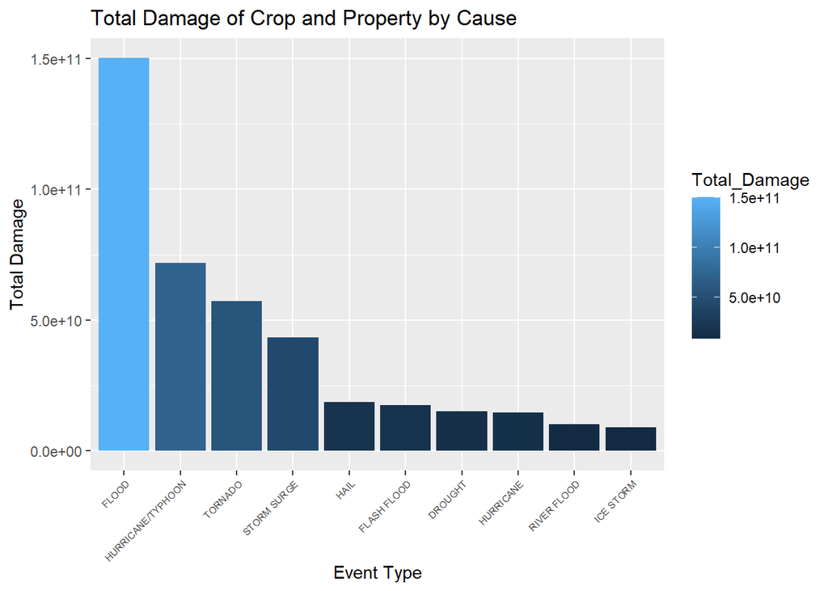

```r
  ggplot(head(StormData_Property_Damage, 10)) +
   geom_col(aes(reorder(EVTYPE, -Total_Damage), Total_Damage, fill = Total_Damage)) +
    theme(axis.text.x = element_text(angle= 45, vjust = 1, hjust = 1, size = 6),
          legend.position = "right") +
    labs(x = "Event Type",
         y = "Total Damage",
         title = "Total Damage of Crop and Property by Cause")
```

If we display again the top 10 Events of total Damages in a table, we can confirm the previous data:

```r
knitr::kable(head(StormData_Property_Damage, 10), caption = "Table of Top 10 events by damage (Property and Crop)")
```

Table of Top 10 events by damage (Property and Crop)

| EVTYPE | Total_Damage |
| --- | --- |
| FLOOD | 150319678257 |
| HURRICANE/TYPHOON | 71913712800 |
| TORNADO | 57352114049 |
| STORM SURGE | 43323541000 |
| HAIL | 18758222016 |
| FLASH FLOOD | 17562129167 |
| DROUGHT | 15018672000 |
| HURRICANE | 14610229010 |
| RIVER FLOOD | 10148404500 |
| ICE STORM | 8967041360 |